# R Package ‘stratifyR’

## 7.6 Application: Comparing Methods for `strata.data`

The following example uses the Iron variable directly to compare the three methods for a 2-strata data-based solution. This illustrates the fundamental limitation of continuous optimisers on empirical data.

```r
data(anaemia)
Iron <- anaemia$Iron
Iron[Iron == min(Iron)] <- -0.001  # as per standard package convention

# DP (recommended for strata.data)
res_dp_s <- strata.data(Iron, h=2, n=350, method="dp")
summary(res_dp_s)
```

```
#> <div style='margin-bottom:0.5rem'><span style='color:#0b7285;font-weight:700'>Stratification summary</span></div>
#> <div><span style='color:#0b7285;font-weight:600'>Strata (h):</span> 2 &nbsp; <span style='color:#0b7285;font-weight:600'>n:</span> 350 &nbsp; <span style='color:#0b7285;font-weight:600'>N:</span> 724</div>
#> <div><span style='color:#0b7285;font-weight:600'>Data range:</span> [-0.0010, 34.7000]  (d = 34.7010)</div>
#> <div><span style='color:#0b7285;font-weight:600'>Best-fit distribution:</span> norm</div>
#>
#>
#>
#> Table: Parameter estimate(s)
#>
#> |Parameter |  Estimate|
#> |:---------|---------:|
#> |mean      | 12.194472|
#> |sd        |  6.026547|
```

Per-stratum results and totals

| Strata | OSB | Wh | Vh | WhSh | nh | Nh | fh |
| --- | --- | --- | --- | --- | --- | --- | --- |
| 1 | 12.58 | 0.58 | 8.83 | 1.724 | 171 | 420 | 0.41 |
| 2 | 34.7 | 0.42 | 18.49 | 1.805 | 179 | 304 | 0.59 |
| Total |  | 1.00 | 27.32 | 3.530 | 350 | 724 | 0.48 |

```r
# COBYLA
res_cob_s <- strata.data(Iron, h=2, n=350, method="cobyla")
summary(res_cob_s)
```

```
#> <div style='margin-bottom:0.5rem'><span style='color:#0b7285;font-weight:700'>Stratification summary</span></div>
#> <div><span style='color:#0b7285;font-weight:600'>Strata (h):</span> 2 &nbsp; <span style='color:#0b7285;font-weight:600'>n:</span> 350 &nbsp; <span style='color:#0b7285;font-weight:600'>N:</span> 724</div>
#> <div><span style='color:#0b7285;font-weight:600'>Data range:</span> [-0.0010, 34.7000]  (d = 34.7010)</div>
#> <div><span style='color:#0b7285;font-weight:600'>Best-fit distribution:</span> norm</div>
#>
#>
#>
#> Table: Parameter estimate(s)
#>
#> |Parameter |  Estimate|
#> |:---------|---------:|
#> |mean      | 12.194472|
#> |sd        |  6.026547|
```

Per-stratum results and totals

| Strata | OSB | Wh | Vh | WhSh | nh | Nh | fh |
| --- | --- | --- | --- | --- | --- | --- | --- |
| 1 | 13.2509 | 0.62 | 9.74 | 1.948 | 194 | 452 | 0.43 |
| 2 | 34.7 | 0.38 | 17.35 | 1.565 | 156 | 272 | 0.57 |
| Total |  | 1.00 | 27.09 | 3.513 | 350 | 724 | 0.48 |

```r
# GLOBAL
res_glob_s <- strata.data(Iron, h=2, n=350, method="global")
summary(res_glob_s)
```

```
#> <div style='margin-bottom:0.5rem'><span style='color:#0b7285;font-weight:700'>Stratification summary</span></div>
#> <div><span style='color:#0b7285;font-weight:600'>Strata (h):</span> 2 &nbsp; <span style='color:#0b7285;font-weight:600'>n:</span> 350 &nbsp; <span style='color:#0b7285;font-weight:600'>N:</span> 724</div>
#> <div><span style='color:#0b7285;font-weight:600'>Data range:</span> [-0.0010, 34.7000]  (d = 34.7010)</div>
#> <div><span style='color:#0b7285;font-weight:600'>Best-fit distribution:</span> norm</div>
#>
#>
#>
#> Table: Parameter estimate(s)
#>
#> |Parameter |  Estimate|
#> |:---------|---------:|
#> |mean      | 12.194472|
#> |sd        |  6.026547|
```

Per-stratum results and totals

| Strata | OSB | Wh | Vh | WhSh | nh | Nh | fh |
| --- | --- | --- | --- | --- | --- | --- | --- |
| 1 | 13.2558 | 0.62 | 9.74 | 1.948 | 194 | 452 | 0.43 |
| 2 | 34.7 | 0.38 | 17.35 | 1.565 | 156 | 272 | 0.57 |
| Total |  | 1.00 | 27.09 | 3.513 | 350 | 724 | 0.48 |

```r
# Direct comparison
cat("DP     OSB:", round(res_dp_s$OSB, 2),   "  WhShTot:", round(res_dp_s$WhShTot, 4), "\n")
```

```
#> DP     OSB: 12.58 34.7   WhShTot: 3.53
```

```r
cat("COBYLA OSB:", round(res_cob_s$OSB, 2),  "  WhShTot:", round(res_cob_s$WhShTot, 4), "\n")
```

```
#> COBYLA OSB: 13.25   WhShTot: 3.513
```

```r
cat("GLOBAL OSB:", round(res_glob_s$OSB, 2), "  WhShTot:", round(res_glob_s$WhShTot, 4), "\n")
```

```
#> GLOBAL OSB: 13.26   WhShTot: 3.513
```

The results show that for data-based stratification, COBYLA and GLOBAL may report a lower WhShTot than DP, with different OSB. This is not because DP is performing worse — it is because the two approaches are minimising different objectives. DP optimises a theoretical $W_h S_h$ computed analytically under the fitted distribution (via `data.root`), while COBYLA and GLOBAL directly minimise the empirical $W_h S_h$ computed from the actual data counts and standard deviations. The reported WhShTot is always empirical, so methods that directly minimise the empirical objective will naturally tend to report a lower value. However, the DP boundaries are theoretically justified: they minimise the expected Neyman cost under the best-fit distributional model, in the same way as `strata.distr`. The empirical boundaries found by COBYLA and GLOBAL are tailored to the specific sample and do not generalise to the underlying population in the same principled way. For this reason, `method = "dp"` remains the recommended and default choice for `strata.data`.

# 8 Application to Numerous Survey Populations

As discussed earlier, the **stratifyR** package is able to handle ten continuous distributions that are quite commonly-used in real-life situations. This section presents a brief overview of these distributions and the application of the proposed method of stratification using real or simulated data which follows a particular distribution. Examples for hypothetical distributions are also presented. For the sake of brevity, the mathematical formulations of the problem of determining the OSB and the DP solution procedure are presented only for the Pareto Type II variable. For all other distributions, only the examples are presented to illustrate the application of the package.

## 8.1 Stratification for a Survey Variable with Pareto Type II Distribution

Let the study variable follow the Pareto Type II distribution on the domain of [$0, +\infty$], its two-parameter probability density function with a state space $y\geq 0$ is given by:
$$\begin{equation}
f(y; s,a)=\dfrac{a\,s^{a}}{(y+s)^{a+1}}, \;\;\;\;\;a,s > 0 \tag{15}
\end{equation}$$

where $\alpha > 0$ is the shape parameter and $s>0$ is the scale parameter of the distribution.

### 8.1.1 MPP Formulation for Pareto Type II Distribution

If the study variable $y$ follows Pareto II (or Lomax) distribution (i.e., $y\sim P(a, s)$) with density function given by (15). By using equations (4)-(6), the formulated MPP given in (10) could be expressed as:
$$\begin{eqnarray}
\textrm{Minimize} \;\;\; \sum_{h=1}^{L} \textit{SQRT} &&
\Biggl\{as^{2a}
\left[\dfrac{(y_{h-1}+l_{h}+s)^{a}-(y_{h-1}+s)^{a}}{(y_{h-1}+s)^{a}(y_{h-1}+l_{h}+s)^{a}}\right]
\nonumber \\[10pt]
&& \times\left[\dfrac{(y_{h-1}+l_{h}+s)^{2-a}}{2-a} -
\dfrac{2s(y_{h-1}+l_{h}+s)^{1-a}}{1-a} \right. \nonumber\\[10pt]
&& - \dfrac{s^2(y_{h-1}+l_{h}+s)^{-a}}{a}
-\dfrac{(y_{h-1}+s)^{2-a}}{2-a}\nonumber\\[10pt]
&& + \left. \dfrac{2s(y_{h-1}+s)^{1-a}}{1-a} +
\dfrac{s^2(y_{h-1}+s)^{-a}}{a}\right] \nonumber\\[10pt]
&& \times
\dfrac{s^{2a}}{(1-a)^{2}}\left[\dfrac{a(y_{h-1}+l_{h})+s}{(y_{h-1}+l_{h}+s)^{a}}
- \dfrac{ay_{h-1}+s}{(y_{h-1}+s)^{a}}
\right]^{2}\Biggr\}\nonumber\\[15pt]
\textrm{subject to} && \;\;\;\; \sum_{h=1}^{L}l_{h} =
d,\nonumber
\\
\textrm{and} && \;\;\;\; l_{h} \geq 0; \;\; h =
1,2,...,L. \tag{16}
\end{eqnarray}$$

where $d=y_{L}-y_{0}$, $a$ and $s$ are parameters of the Pareto Type II distribution.

### 8.1.2 DP Solution for Pareto Type II Distribution

To solve the MPP (16) using the DP technique as a solution procedure, we apply the algorithm, that is, the solution proceure using Dynamic Progrmming technique discussed earlier in Section 4. After substituting the quatity $y_{h-1}=y_{0} + d_{h} - l_{h}$, the recurrence relations (11) and (12) are reduced to:

For the first stage, $k=1$, at $l_{1}^{*}=d_{1}$:

$$\begin{eqnarray}
\Phi_{1}d_{1}&=& \textrm{Sqrt}\Biggl\{
as^{2a}\left[\dfrac{(d_{1}+y_{0}+s)^{a}-(y_{0}+s)^{a}}{(y_{0}+s)^{a}(d_{1}+y_{0}+s)^{a}}\right]
\nonumber\\[10pt]
&&\times\left[\dfrac{(d_{1}+y_{0}+s)^{2-a}}{2-a} -
\dfrac{2s(d_{1}+y_{0}+s)^{1-a}}{1-a} \right. \nonumber\\[10pt]
&&- \dfrac{s^2(d_{1}+y_{0}+s)^{-a}}{a}
-\dfrac{(y_{0}+s)^{2-a}}{2-a}\nonumber\\[10pt]
&&+\left. \dfrac{2s(y_{0}+s)^{1-a}}{1-a} +
\dfrac{s^2(y_{0}+s)^{-a}}{a}\right] \nonumber\\[10pt]
&&\times
\dfrac{s^{2a}}{(1-a)^{2}}\left[\dfrac{a(d_{1}+y_{0})+s}{(d_{1}+y_{0}+s)^{a}}
- \dfrac{ay_{0}+s}{(y_{0}+s)^{a}} \right]^{2}\Biggr\} \tag{17}
\end{eqnarray}$$

And for the stages $k\geq2$:

$$\begin{eqnarray}
\Phi_{k}d_{k}&=&\min_{0\leq l_{k}\leq d_{k}}\Biggl\{
\textrm{Sqrt}\Biggl\{
as^{2a}\left[\dfrac{(d_{k}+y_{0}+s)^{a}-(d_{k}+l_{k}+y_{0}+s)^{a}}{(d_{k}+l_{k}+y_{0}+s)^{a}(d_{k}+y_{0}+s)^{a}}\right]
\nonumber\\[10pt]
&&\times\left[\dfrac{(d_{k}+y_{0}+s)^{2-a}}{2-a} -
\dfrac{2s(d_{k}+y_{0}+s)^{1-a}}{1-a} \right. \nonumber\\[10pt]
&&- \dfrac{s^2(d_{k}+y_{0}+s)^{-a}}{a}
-\dfrac{(d_{k}+l_{k}+y_{0}+s)^{2-a}}{2-a}\nonumber\\[10pt]
&&+\left. \dfrac{2s(d_{k}+l_{k}+y_{0}+s)^{1-a}}{1-a} +
\dfrac{s^2(d_{k}+l_{k}+y_{0}+s)^{-a}}{a}\right] \nonumber\\[10pt]
&&\times
\dfrac{s^{2a}}{(1-a)^{2}}\left[\dfrac{a(d_{k}+y_{0})+s}{(d_{k}+y_{0}+s)^{a}}-
\dfrac{a(d_{k}+l_{k}+y_{0})+s}{(d_{k}+l_{k}+y_{0}+s)^{a}} \right]^{2}
\Biggr\} + \Phi_{k-1}(d_{k}-l_{k})\Biggr\}. \tag{18}
\end{eqnarray}$$

The recurrence relations (17) and (18) are solved using the DP technique to determine the OSB.

### 8.1.3 A Numerical Example for Pareto Type II Distribution

A dataset for a univariate population of size $N=5000$ with the study variable that follows Pareto Type II distribution ($pareto\_data$) was simulated using parameters $shape=5$ and $scale=8$ to demonstrate the application of the **strata.data()** function to determine the OSB and other quantites. The data exhibits a 2-parameter Pareto Type II distribution with the MLE estimates of the parameters as $shape=5.026907$ and $scale=8.191676$. The minimum and maximum values in the simulated data are $[y_{0}, y_{L}] = [0.0002193, 38.56871]$, which implies that $d=38.56849$.

To construct the OSB (a 2-strata solution, i.e., $h = 2$) for the $pareto\_data$ with a fixed total sample size of $500$, we use the following codes:

```r
set.seed(8235411)
pareto_data <- actuar::rpareto(5000, shape=5, scale=8)

dpareto <- actuar::dpareto
ppareto <- actuar::ppareto
qpareto <- actuar::qpareto

head(pareto_data)
```

```
#> [1] 1.8464786 0.9226109 1.1079785 9.7699864 4.5600912 0.0441124
```

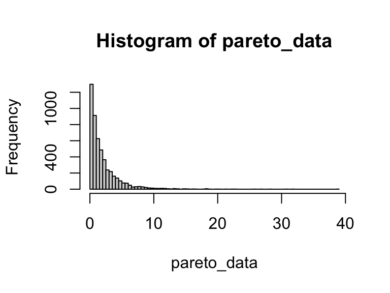

```r
hist(pareto_data, breaks=100)
```

```r
min(pareto_data); max(pareto_data); d=max(pareto_data)-min(pareto_data);d
```

```
#> [1] 0.0002192696
#> [1] 38.56871
#> [1] 38.56849
```

```r
fit <- fitdistrplus::fitdist(pareto_data, "pareto", start = list(shape = 1, scale = 500))
fit
```

```
#> Fitting of the distribution ' pareto ' by maximum likelihood
#> Parameters:
#>       estimate Std. Error
#> shape 5.026907  0.4337687
#> scale 8.191676  0.8358576
```

```r
res <- strata.data(pareto_data, h = 2, n=500) # a 2-strata solution
summary(res)
```

```
#> <div style='margin-bottom:0.5rem'><span style='color:#0b7285;font-weight:700'>Stratification summary</span></div>
#> <div><span style='color:#0b7285;font-weight:600'>Strata (h):</span> 2 &nbsp; <span style='color:#0b7285;font-weight:600'>n:</span> 500 &nbsp; <span style='color:#0b7285;font-weight:600'>N:</span> 5000</div>
#> <div><span style='color:#0b7285;font-weight:600'>Data range:</span> [0.0002, 38.5687]  (d = 38.5685)</div>
#> <div><span style='color:#0b7285;font-weight:600'>Best-fit distribution:</span> weibull</div>
#>
#>
#>
#> Table: Parameter estimate(s)
#>
#> |Parameter | Estimate|
#> |:---------|--------:|
#> |shape     | 0.875786|
#> |scale     | 1.895872|
```

Per-stratum results and totals

| Strata | OSB | Wh | Vh | WhSh | nh | Nh | fh |
| --- | --- | --- | --- | --- | --- | --- | --- |
| 1 | 2.73 | 0.76 | 0.54 | 0.560 | 205 | 3803 | 0.05 |
| 2 | 38.57 | 0.24 | 11.34 | 0.806 | 295 | 1197 | 0.25 |
| Total |  | 1.00 | 11.88 | 1.366 | 500 | 5000 | 0.10 |

Similarly, in order to find the OSB and other quantities, we can apply the **strata.distr()** function to a Pareto Type II population. Let us assume from past knowledge that the study variable in the population follows Pareto Type II distribution with the given attributes such as the $shape=5.05, scale=8.20, initial\,value=0.15$ and $distance=38.55$. Then, if a sample of size $n=500$ is drawn from the population of size $N=5000$, we can execute the following command to obtain the results:

```r
res <- strata.distr(h=2, initval=0.15, dist=38.55, distr = "pareto",
             params = c(shape=5.05, scale=8.20), n=500, N=5000)
```

```
#> The program is running, it'll take some time!
```

```r
summary(res)
```

```
#> <div style='margin-bottom:0.5rem'><span style='color:#0b7285;font-weight:700'>Stratification summary</span></div>
#> <div><span style='color:#0b7285;font-weight:600'>Strata (h):</span> 2 &nbsp; <span style='color:#0b7285;font-weight:600'>n:</span> 500 &nbsp; <span style='color:#0b7285;font-weight:600'>N:</span> 5000</div>
#> <div><span style='color:#0b7285;font-weight:600'>Data range:</span> [0.1500, 38.7000]  (d = 38.5500)</div>
#> <div><span style='color:#0b7285;font-weight:600'>Best-fit distribution:</span> pareto</div>
#>
#>
#>
#> Table: Parameter estimate(s)
#>
#> |Parameter | Estimate|
#> |:---------|--------:|
#> |shape     |     5.05|
#> |scale     |     8.20|
```

Per-stratum results and totals

| Strata | OSB | Wh | Vh | WhSh | nh | Nh | fh |
| --- | --- | --- | --- | --- | --- | --- | --- |
| 1 | 3.21 | 0.81 | 0.67 | 0.592 | 241 | 4057 | 0.06 |
| 2 | 38.7 | 0.19 | 11.42 | 0.637 | 259 | 943 | 0.27 |
| Total |  | 1.00 | 12.09 | 1.229 | 500 | 5000 | 0.10 |

## 8.2 Stratification for a Survey Variable with Triangular Distribution

Let the study variable follow Triangular distribution on the domain of [$a, b$], its three-parameter probability density function with a state space $y\geq 0$ is given by:
$$\begin{equation}
f(y) =
\begin{cases}
\dfrac{2(y-a)}{(b-a)(c-a)}; & y \in [a, c]\\[10pt]
\dfrac{2(b-y)}{(b-a)(b-c)}; & y \in (c,b] \\
\end{cases} \tag{19}
\end{equation}$$

where $a$ is the location parameter, $b$ is the scale parameter and $c$ is the shape parameter of the distribution.

Then, formulating the problem as an MPP and solving the recurrence relations as discussed above for Pareto II variate, the OSB are obtained.

### 8.2.1 DP Solution for Triangular Distribution

To solve the MPP formulated for Triangular distribution (19), we apply the algorithm using the DP technique discussed in Section 4. The recurrence relations used to determine the OSB are given by:

For the first stage, $k=1$, at $l_{1}^{*}=d_{1}$:

$$\begin{eqnarray}
\Phi_{1}d_{1}&=& \textrm{Sqrt}\Biggl\{
\sum_{h=1}^{\lambda_{1}}
\dfrac{d_{1}^{2}\sqrt{d_{1}^{2}+6(y_{0}-a)d_{1}+6(y_{0}-a)^{2}}}{3\sqrt{2}(b-a)(c-a)}
+
\sum_{h=\lambda_{2}}^{L}\dfrac{d_{1}^{2}\sqrt{6(b-y_{0})^{2}-6(b-y_{0})d_{1}+d_{1}^{2}}}{3\sqrt{2}(b-a)(b-c)}\Biggr\}
\tag{20}
\end{eqnarray}$$

And for the stages $k\geq2$:

$$\begin{eqnarray}
\Phi_{k}d_{k}&=&\min_{0\leq l_{k}\leq d_{k}}\Biggl\{
\textrm{Sqrt}\Biggl\{\sum_{h=1}^{\lambda_{1}}
\dfrac{l_{k}^{2}\sqrt{l_{k}^{2}+6a_{k}l_{k}+6a_{k}^{2}}}{3\sqrt{2}(b-a)(c-a)}
+\sum_{h=\lambda_{2}}^{L}\dfrac{l_{k}^{2}\sqrt{6b_{k}^{2}-6b_{k}l_{k}+l_{k}^{2}}}{3\sqrt{2}(b-a)(b-c)}\Biggr\}
+ \Phi_{k-1}(d_{k}-l_{k})\Biggr\} \tag{21}
\end{eqnarray}$$

where $a_{k}=d_{k}-l_{k}+y_{0}-a$ and $b_{k}=b-d_{k}+l_{k}-y_{0}+a$.

Substituting the values of $a$, $b$, $c$, $y_{0}$ and $d$, the OSW ($l_{h}^{*}$) and the OSB ($y_{h}^{*}=y_{h-1}^{*}-l_{h}^{*}$) are obtained by executing the **strata.data()** function.

### 8.2.2 A Numerical Example for Triangular Distribution

To construct the OSB ($h = 2$) for the `final_marks’ data with a fixed total sample size of $150$, we use the following code:

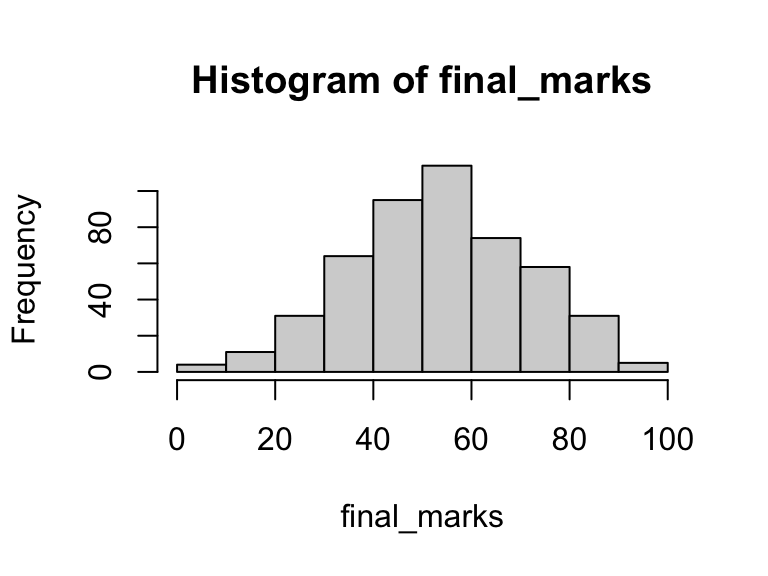

```r
data(math)
final_marks <- math$final_marks
hist(final_marks)
```

```r
res <- strata.data(final_marks, h = 2, n=150) # a 2-strata solution
summary(res)
```

```
#> <div style='margin-bottom:0.5rem'><span style='color:#0b7285;font-weight:700'>Stratification summary</span></div>
#> <div><span style='color:#0b7285;font-weight:600'>Strata (h):</span> 2 &nbsp; <span style='color:#0b7285;font-weight:600'>n:</span> 150 &nbsp; <span style='color:#0b7285;font-weight:600'>N:</span> 487</div>
#> <div><span style='color:#0b7285;font-weight:600'>Data range:</span> [7.0000, 97.0000]  (d = 90.0000)</div>
#> <div><span style='color:#0b7285;font-weight:600'>Best-fit distribution:</span> weibull</div>
#>
#>
#>
#> Table: Parameter estimate(s)
#>
#> |Parameter |  Estimate|
#> |:---------|---------:|
#> |shape     |  3.371526|
#> |scale     | 59.909598|
```

Per-stratum results and totals

| Strata | OSB | Wh | Vh | WhSh | nh | Nh | fh |
| --- | --- | --- | --- | --- | --- | --- | --- |
| 1 | 53.44 | 0.49 | 114.72 | 5.278 | 74 | 240 | 0.31 |
| 2 | 97 | 0.51 | 116.01 | 5.463 | 76 | 247 | 0.31 |
| Total |  | 1.00 | 230.73 | 10.741 | 150 | 487 | 0.31 |

Similarly, in order to find the OSB and other quantities, we can apply the **strata.distr()** function to a Triangular population. Based on the assumption from past knowledge that the population follows Triangular distribution with the given attributes such as the initial value, distance, parameters, etc., we can execute the following command to obtain the results:

```r
data(math)
final_marks <- math$final_marks
a <- min(final_marks); b <- max(final_marks)
a; b; d <- b - a; d
```

```
#> [1] 7
#> [1] 97
#> [1] 90
```

```r
# Estimate parameters: fix min and max to sample bounds, estimate only mode by MLE
br <- pretty(final_marks, n = 20)
hh <- hist(final_marks, breaks = br, plot = FALSE)
m0 <- hh$mids[which.max(hh$counts)]          # histogram mode proxy
fit <- fitdist(final_marks, distr = "triang", method = "mle",
               start   = list(mode = m0),
               fix.arg = list(min = a, max = b))
fit
```

```
#> Fitting of the distribution ' triang ' by maximum likelihood
#> Parameters:
#>      estimate
#> mode     52.5
#> Fixed parameters:
#>     value
#> min     7
#> max    97
```

```r
# 2-strata solution
res <- strata.distr(h=2, initval=7, dist=90, distr = "triangle",
      params = c(min=7, max=97, mode=54), n=150, N=352)
```

```
#> The program is running, it'll take some time!
```

```r
summary(res)
```

```
#> <div style='margin-bottom:0.5rem'><span style='color:#0b7285;font-weight:700'>Stratification summary</span></div>
#> <div><span style='color:#0b7285;font-weight:600'>Strata (h):</span> 2 &nbsp; <span style='color:#0b7285;font-weight:600'>n:</span> 150 &nbsp; <span style='color:#0b7285;font-weight:600'>N:</span> 352</div>
#> <div><span style='color:#0b7285;font-weight:600'>Data range:</span> [7.0000, 97.0000]  (d = 90.0000)</div>
#> <div><span style='color:#0b7285;font-weight:600'>Best-fit distribution:</span> triangle</div>
#>
#>
#>
#> Table: Parameter estimate(s)
#>
#> |Parameter | Estimate|
#> |:---------|--------:|
#> |min       |        7|
#> |max       |       97|
#> |mode      |       54|
```

Per-stratum results and totals

| Strata | OSB | Wh | Vh | WhSh | nh | Nh | fh |
| --- | --- | --- | --- | --- | --- | --- | --- |
| 1 | 53 | 0.5 | 117.56 | 5.424 | 77 | 176 | 0.44 |
| 2 | 97 | 0.5 | 107.46 | 5.181 | 73 | 176 | 0.42 |
| Total |  | 1.0 | 225.01 | 10.604 | 150 | 352 | 0.43 |

## 8.3 Stratification for a Survey Variable with Right-Triangular Distribution

If a study variable follows the Right-Triangular distribution on the domain of [$a, b$], its two-parameter probability density function is given by:

$$\begin{equation}
f(y) =
\begin{cases}
\dfrac{2(b-y)}{(b-a)^2}; & y \in [a, b]\\
0; & otherwise \\
\end{cases} \tag{22}
\end{equation}$$

where $a$ is the location parameter and $b$ is the scale parameter of the distribution.

### 8.3.1 DP Solution for Right-Triangular Distribution

To solve the MPP formulated for Right-Triangular distribution (22), we apply the algorithm using the DP technique discussed in Section 4. The recurrence relations used to determine the OSB are given by:

For the first stage, $k=1$, at $l_{1}^{*}=d_{1}$:

$$\begin{eqnarray}
\Phi_{1}d_{1}&=& \textrm{Sqrt}\Biggl\{
\left[\dfrac{d_{1}(2(y_{0}-a)-d_{1})}{(b-a)^{2}}\right]^{2}\times\left[\dfrac{d_{1}^{2}(d_{1}^{2}-6(y_{0}-a)d_{1}+6a_{h}^{2})}{18(2(y_{0}-a)-d_{1})^{2}}\right]\Biggr\}
\tag{23}
\end{eqnarray}$$

And for the stages $k\geq2$:

$$\begin{eqnarray}
\Phi_{k}d_{k}&=&\min_{0\leq l_{k}\leq d_{k}}\Biggl\{
\textrm{Sqrt}\Biggl\{\left[\dfrac{l_{k}(2a_{k}-l_k)}{(b-a)^{2}}\right]^{2}
\times\left[\dfrac{l_{k}^{2}(l_{k}^{2}-6a_{k}l_{k}+6a_{k}^{2})}{18(2a_{k}-l_{k})^{2}}\right]\Biggr\}
+ \Phi_{k-1}(d_{k}-l_{k})\Biggr\} \tag{24}
\end{eqnarray}$$

where $a_{k}=b-d_{k}+l_{k}-y_{0}$.

Substituting the values of $a$, $b$, $y_{0}$ and $d$, the OSW ($l_{h}^{*}$) and the OSB ($y_{h}^{*}=y_{h-1}^{*}-l_{h}^{*}$) are obtained by executing the **strata.data()** function.

### 8.3.2 A Numerical Example for Right-Triangular Distribution

To construct the OSB ($h = 2$) for the Right-Triangular data with a fixed total sample size of $500$, we use the following code:

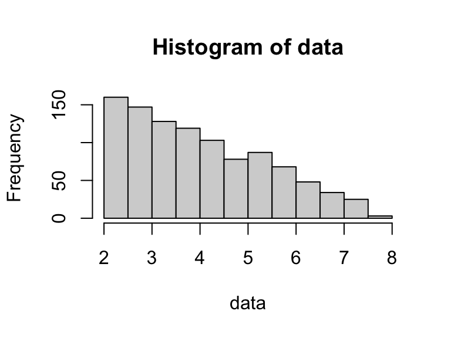

```r
#Generate RT data
set.seed(12546)
data <- rtriangle(n=1000, a=2, b=8, c=2) #right-triangular since a=c
hist(data)
```

```r
res <- strata.data(data, h = 2, n=500) # a 2-strata solution
summary(res)
```

```
#> <div style='margin-bottom:0.5rem'><span style='color:#0b7285;font-weight:700'>Stratification summary</span></div>
#> <div><span style='color:#0b7285;font-weight:600'>Strata (h):</span> 2 &nbsp; <span style='color:#0b7285;font-weight:600'>n:</span> 500 &nbsp; <span style='color:#0b7285;font-weight:600'>N:</span> 1000</div>
#> <div><span style='color:#0b7285;font-weight:600'>Data range:</span> [2.0001, 7.8387]  (d = 5.8387)</div>
#> <div><span style='color:#0b7285;font-weight:600'>Best-fit distribution:</span> lnorm</div>
#>
#>
#>
#> Table: Parameter estimate(s)
#>
#> |Parameter | Estimate|
#> |:---------|--------:|
#> |meanlog   | 1.327465|
#> |sdlog     | 0.353496|
```

Per-stratum results and totals

| Strata | OSB | Wh | Vh | WhSh | nh | Nh | fh |
| --- | --- | --- | --- | --- | --- | --- | --- |
| 1 | 4.17 | 0.58 | 0.38 | 0.359 | 246 | 582 | 0.42 |
| 2 | 7.84 | 0.42 | 0.78 | 0.369 | 254 | 418 | 0.61 |
| Total |  | 1.00 | 1.16 | 0.727 | 500 | 1000 | 0.50 |

Similarly, in order to find the OSB and other quantities, we can apply the **strata.distr()** function to a Right-Triangular population. Based on the assumption from past knowledge that the population follows Right-Triangular distribution with the given attributes such as the initial value, distance, parameters, etc., we can execute the following command to obtain the results:

```r
res <- strata.distr(h=2, initval=1.007202, dist=0.992781, distr = "rtriangle",
         params = c(min=2, max=10, mode=2), n=500, N=1000)
```

```
#> The program is running, it'll take some time!
```

```r
summary(res)
```

```
#> <div style='margin-bottom:0.5rem'><span style='color:#0b7285;font-weight:700'>Stratification summary</span></div>
#> <div><span style='color:#0b7285;font-weight:600'>Strata (h):</span> 2 &nbsp; <span style='color:#0b7285;font-weight:600'>n:</span> 500 &nbsp; <span style='color:#0b7285;font-weight:600'>N:</span> 1000</div>
#> <div><span style='color:#0b7285;font-weight:600'>Data range:</span> [1.0072, 2.0000]  (d = 0.9928)</div>
#> <div><span style='color:#0b7285;font-weight:600'>Best-fit distribution:</span> rtriangle</div>
#>
#>
#>
#> Table: Parameter estimate(s)
#>
#> |Parameter | Estimate|
#> |:---------|--------:|
#> |min       |        2|
#> |max       |       10|
#> |mode      |        2|
```

Per-stratum results and totals

| Strata | OSB | Wh | Vh | WhSh | nh | Nh | fh |
| --- | --- | --- | --- | --- | --- | --- | --- |
| 1 | 1.5 | -0.13 | 0.02 | 0.019 | -129 | -129 | 1.00 |
| 2 | 2 | 1.13 | 0.02 | 0.019 | 629 | 1129 | 0.56 |
| Total |  | 1.00 | 0.04 | 0.038 | 500 | 1000 | 0.50 |

## 8.4 Stratification for a Survey Variable with Weibull Distribution

If the study variable follows the Weibull distribution on the interval $[y_{0}, y_{L}]$, its two-parameter probability density function with a state space $y\geq 0$ is given by:
$$\begin{equation}
f(y; \theta,
r)=\dfrac{r}{\theta}\left(\dfrac{y}{\theta}\right)^{r-1}e^{-\left(y/\theta\right)^{r}},
\;\;\;\;\;y\geq 0 \tag{25}
\end{equation}$$

where $r > 0$ is the shape parameter and $\theta > 0$ is the scale parameter of the distribution.

### 8.4.1 DP Solution for Weibull Distribution

For the first stage, $k=1$, at $l_{1}^{*}=d_{1}$:

$$\begin{eqnarray}
\Phi_{1}d_{1}&=& \textrm{Sqrt}\Biggl\{
\theta^{2}\,\Gamma\left(1+\dfrac{2}{r}
\right)\left[e^{-\left(\frac{y_{0}}{\theta}\right)^{r}}-e^{-\left(\frac{d_{1}+y_{0}}{\theta}\right)^{r}}\right]
\nonumber \\[10pt]
&&\times
\left[Q\left(1+\dfrac{2}{r},\left(\dfrac{y_{0}}{\theta}\right)^{r}\right)-
Q\left(1+\dfrac{2}{r},\left(\dfrac{d_{1}+y_{0}}{\theta}\right)^{r}\right)\right]\nonumber\\[10pt]
&&-\theta^{2}\left[\Gamma\left(1+\dfrac{1}{r}\right)\left
[Q\left(1+\dfrac{1}{r},\left(\dfrac{y_{0}}{\theta}\right)^{r}\right)\right.\right.\nonumber\\[10pt]
&&-Q\left.\left.\left(1+\dfrac{1}{r},\left(\dfrac{d_{1}+y_{0}}{\theta}\right)^{r}\right)\right]\right]^{2}\Biggr\}
\tag{26}
\end{eqnarray}$$

And for the stages $k\geq2$:

$$\begin{eqnarray}
\Phi_{k}d_{k}&=&\min_{0\leq l_{k}\leq d_{k}}\Biggl\{
\textrm{Sqrt}\Biggl\{
\theta^{2}\,\Gamma\left(1+\dfrac{2}{r}
\right)\left[e^{-\left(\frac{d_{k}-l_{k}+y_{0}}{\theta}\right)^{r}}-e^{-\left(\frac{d_{k}+y_{0}}{\theta}\right)^{r}}\right]\nonumber\\[10pt]
&&\times
\left[Q\left(1+\dfrac{2}{r},\left(\dfrac{d_{k}-l_{k}+y_{0}}{\theta}\right)^{r}\right)-
Q\left(1+\dfrac{2}{r},\left(\dfrac{d_{k}+y_{0}}{\theta}\right)^{r}\right)\right]\nonumber\\[15pt]
&&-\theta^{2}\left[\Gamma\left(1+\dfrac{1}{r}\right)\left
[Q\left(1+\dfrac{1}{r},\left(\dfrac{d_{k}-l_{k}+y_{0}}{\theta}\right)^{r}\right)\right.\right.\nonumber\\[15pt]
&&-Q\left.\left.\left(1+\dfrac{1}{r},\left(\dfrac{d_{k}+y_{0}}{\theta}\right)^{r}\right)\right]\right]^{2}\Biggr\}+\Phi_{k-1}(d_{k}-l_{k})\Biggr\}.
\tag{27}
\end{eqnarray}$$

The recurrence relations (26) and (27) are solved using the DP technique to determine the OSB.

### 8.4.2 A Numerical Example for Weibull Distribution

A health data of size $N=724$, called ‘anaemia’ data (Reddy et al. (2014)), is used to demonstrate the application of the **stratifyR** package on Weibull population. The ‘anaemia’ data comes from the National Nutritional Survey on the ``Micronutrient Status of Women in Fiji” and has many variables such as level of Iron, Folate, Zinc, etc. In this example, the variable Iron is used since it exhibits a 2-parameter Weibull distribution with the shape and scale parameters as $r = 2.144586$ and $\theta = 13.790744$ respectively. The minimum and maximum values are $[y_{0}, y_{L}] = [1.5, 34.7]$, which implies that $d=33.2$.

To construct the OSB ($h = 2$) for the Iron data with a fixed total sample size of $500$, we use the following codes:

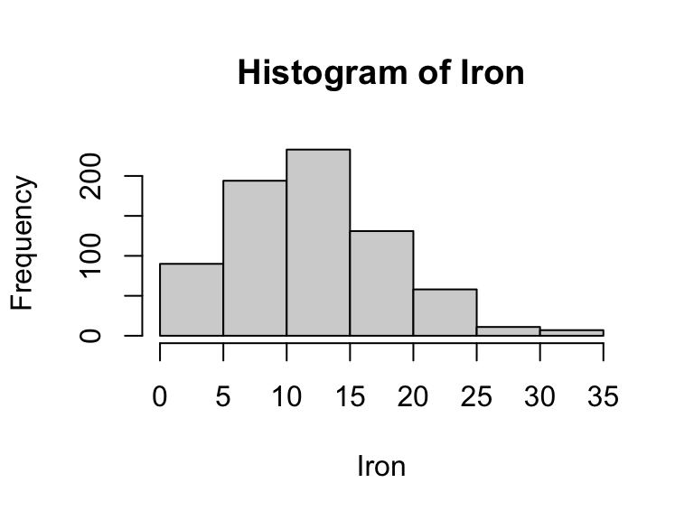

```r
data(anaemia) #using the anaemia data
Iron <- anaemia$Iron
hist(Iron)
```

```r
min_value <- min(Iron) # Find the minimum value
Iron[Iron == min_value] <- -0.001 # Replace the minimum value with -0.001
res <- strata.data(Iron, h = 2, n=500) # a 2-strata solution
summary(res)
```

```
#> <div style='margin-bottom:0.5rem'><span style='color:#0b7285;font-weight:700'>Stratification summary</span></div>
#> <div><span style='color:#0b7285;font-weight:600'>Strata (h):</span> 2 &nbsp; <span style='color:#0b7285;font-weight:600'>n:</span> 500 &nbsp; <span style='color:#0b7285;font-weight:600'>N:</span> 724</div>
#> <div><span style='color:#0b7285;font-weight:600'>Data range:</span> [-0.0010, 34.7000]  (d = 34.7010)</div>
#> <div><span style='color:#0b7285;font-weight:600'>Best-fit distribution:</span> norm</div>
#>
#>
#>
#> Table: Parameter estimate(s)
#>
#> |Parameter |  Estimate|
#> |:---------|---------:|
#> |mean      | 12.194472|
#> |sd        |  6.026547|
```

Per-stratum results and totals

| Strata | OSB | Wh | Vh | WhSh | nh | Nh | fh |
| --- | --- | --- | --- | --- | --- | --- | --- |
| 1 | 12.58 | 0.58 | 8.83 | 1.724 | 244 | 420 | 0.58 |
| 2 | 34.7 | 0.42 | 18.49 | 1.805 | 256 | 304 | 0.84 |
| Total |  | 1.00 | 27.32 | 3.530 | 500 | 724 | 0.69 |

Similarly, in order to find the OSB and other quantities, we can apply the **strata.distr()** function to a Weibull population. Based on the assumption from past knowledge that the population follows Weibull distribution with the given attributes such as the initial value, distance, parameters, etc., we can execute the following command to obtain the results:

```r
res <- strata.distr(h=2, initval=2.9, dist=55.9, distr = "weibull",
       params = c(shape=2.144586, scale=13.790744), n=500, N=5000)
```

```
#> The program is running, it'll take some time!
```

```r
summary(res)
```

```
#> <div style='margin-bottom:0.5rem'><span style='color:#0b7285;font-weight:700'>Stratification summary</span></div>
#> <div><span style='color:#0b7285;font-weight:600'>Strata (h):</span> 2 &nbsp; <span style='color:#0b7285;font-weight:600'>n:</span> 500 &nbsp; <span style='color:#0b7285;font-weight:600'>N:</span> 5000</div>
#> <div><span style='color:#0b7285;font-weight:600'>Data range:</span> [2.9000, 58.8000]  (d = 55.9000)</div>
#> <div><span style='color:#0b7285;font-weight:600'>Best-fit distribution:</span> weibull</div>
#>
#>
#>
#> Table: Parameter estimate(s)
#>
#> |Parameter |  Estimate|
#> |:---------|---------:|
#> |shape     |  2.144586|
#> |scale     | 13.790744|
```

Per-stratum results and totals

| Strata | OSB | Wh | Vh | WhSh | nh | Nh | fh |
| --- | --- | --- | --- | --- | --- | --- | --- |
| 1 | 13.05 | 0.59 | 7.49 | 1.516 | 239 | 2943 | 0.08 |
| 2 | 58.8 | 0.41 | 16.28 | 1.660 | 261 | 2057 | 0.13 |
| Total |  | 1.00 | 23.77 | 3.176 | 500 | 5000 | 0.10 |

## 8.5 Stratification for a Survey Variable with Gamma Distribution

If the study variable follows the Gamma distribution (i.e., $y\sim \Gamma(r, \theta)$) on the interval $[y_{0}, y_{L}]$, it has the following two-parameter probability density function:

$$\begin{equation}
f(y;r,\theta)=\dfrac{1}{\theta^{r}\Gamma(r)}\,y^{r-1}e^{-\dfrac{y}{\theta}},\;\;\;\;\;\;\;y>0;\;\;r,\theta>0,
\tag{28}
\end{equation}$$

$$\begin{equation}\label{222}
\Gamma(r)=\int_{0}^{\infty}t^{r-1}e^{-t}\,dt,\;\;\;\;\;\; r > 0.
\tag{29}
\end{equation}$$

The function in equation $(\ref{222})$ is also defined by an upper incomplete gamma function $\Gamma(r,x)$ and a lower incomplete gamma function $\gamma(r,x)$, respectively, as follows:

$$\begin{eqnarray}
\Gamma(r,y)=\int_{y}^{\infty}t^{r-1}e^{-t}\,dt;\label{223} \tag{30}\\
\gamma(r,y)=\int_{0}^{y}t^{r-1}e^{-t}\,dt.\label{224} \tag{31}
\end{eqnarray}$$

There also exist regularized/normalised incomplete Gamma functions which give a value restricted between $0$ and $1$ and can be stated as:

$$\begin{eqnarray}
Q(r,y)=\dfrac{1}{\Gamma(r)}\int_{y}^{\infty}t^{r-1}e^{-t}\,dt,\;\;\;\;\;\;r,y>0;\;\;\Gamma(r)\neq0;\label{225}
\tag{32}\\
P(r,y)=\dfrac{1}{\Gamma(r)}\int_{0}^{y}t^{r-1}e^{-t}\,dt,\;\;\;\;\;\;r,y>0;\;\;\Gamma(r)\neq0,\label{226}
\tag{33}
\end{eqnarray}$$

### 8.5.1 DP Solution for Gamma Distribution

To solve the MPP formulated for Gamma distribution (28), we apply the algorithm using the DP technique discussed in Section 4. The recurrence relations used to determine the OSB are given by:

For the first stage, $k=1$, at $l_{1}^{*}=d_{1}$:

$$\begin{eqnarray}
\Phi_{1}d_{1}&=& \textrm{Sqrt}\Biggl\{
\theta^{2}\,r(r+1)\left[
Q\left(r,\dfrac{y_{0}}{\theta}\right)-Q\left(r,\dfrac{d_{1}+y_{0}}{\theta}\right)\right]\nonumber\\[10pt]
&&\times\left[Q\left(r+2,\dfrac{y_{0}}{\theta}\right)-Q\left(r+2,\dfrac{d_{1}+y_{0}}{\theta}\right)
\right]\nonumber\\[10pt]
&&-\theta^{2}r^{2}\left[
Q\left(r+1,\dfrac{y_{0}}{\theta}\right)-Q\left(r+1,\dfrac{d_{1}+y_{0}}{\theta}\right)\right]^{2}\Biggr\}
\tag{34}
\end{eqnarray}$$

And for the stages $k\geq2$:

$$\begin{eqnarray}
\Phi_{k}d_{k}&=&\min_{0\leq l_{k}\leq d_{k}}\Biggl\{
\textrm{Sqrt}\Biggl\{
\theta^{2}\,r(r+1)\left[
Q\left(r,\dfrac{d_{k}-l_{k}+y_{0}}{\theta}\right.\right)\nonumber\\[10pt]
&&-\left.Q\left(r,\dfrac{d_{k}+y_{0}}{\theta}\right)\right]
\times\left[
Q\left(r+2,\dfrac{d_{k}-l_{k}+y_{0}}{\theta}\right.\right)\nonumber\\[10pt]
&&-\left.Q\left(r+2,\dfrac{d_{k}+y_{0}}{\theta}\right)
\right]-\theta^{2}r^{2}\times\left[
Q\left(r+1,\dfrac{d_{k}-l_{k}+y_{0}}{\theta}\right)\right.\nonumber\\[10pt]
&&-\left.Q\left(r+1,\dfrac{d_{k}+y_{0}}{\theta}\right)\right]^{2}\Biggr\}+\Phi_{k-1}(d_{k}-l_{k})\Biggr\}.
\tag{35}
\end{eqnarray}$$

The recurrence relations (34) and (35) are solved using the DP technique to determine the OSB.

### 8.5.2 A Numerical Example for Gamma Distribution

Again, the health data of size $N=724$, derived from the ‘National Nutritional Survey’ on the ‘Micronutrient Status of Women in Fiji’ is used to demonstrate the application of the **stratifyR** package on Gamma population. In this example, the variable Folate is used since it exhibits a 2-parameter Gamma distribution with the shape and scale parameters as $r = 6.9922$ and $\theta = 2.5785$ respectively. The minimum and maximum values are $[y_{0}, y_{L}] = [4.9, 45.4]$, which implies that $d=40.5$.

To construct the OSB ($h = 2$) for the Folate data with a fixed total sample size of $500$, we use the following codes:

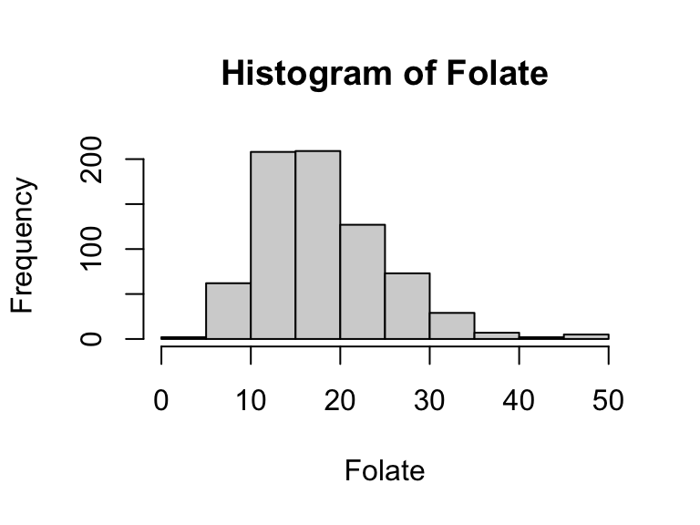

```r
data(anaemia)
Folate <- anaemia$Folate
hist(Folate)
```

```r
min_value <- min(Folate) # Find the minimum value
Folate[Folate == min_value] <- -0.001 # Replace the minimum value with -0.001
res <- strata.data(Folate, h = 2, n=500) # a 2-strata solution
summary(res)
```

```
#> <div style='margin-bottom:0.5rem'><span style='color:#0b7285;font-weight:700'>Stratification summary</span></div>
#> <div><span style='color:#0b7285;font-weight:600'>Strata (h):</span> 2 &nbsp; <span style='color:#0b7285;font-weight:600'>n:</span> 500 &nbsp; <span style='color:#0b7285;font-weight:600'>N:</span> 724</div>
#> <div><span style='color:#0b7285;font-weight:600'>Data range:</span> [-0.0010, 45.4000]  (d = 45.4010)</div>
#> <div><span style='color:#0b7285;font-weight:600'>Best-fit distribution:</span> norm</div>
#>
#>
#>
#> Table: Parameter estimate(s)
#>
#> |Parameter |  Estimate|
#> |:---------|---------:|
#> |mean      | 18.017124|
#> |sd        |  6.985322|
```

Per-stratum results and totals

| Strata | OSB | Wh | Vh | WhSh | nh | Nh | fh |
| --- | --- | --- | --- | --- | --- | --- | --- |
| 1 | 18.13 | 0.56 | 9.85 | 1.752 | 210 | 404 | 0.52 |
| 2 | 45.4 | 0.44 | 29.95 | 2.419 | 290 | 320 | 0.91 |
| Total |  | 1.00 | 39.80 | 4.170 | 500 | 724 | 0.69 |

Similarly, in order to find the OSB and other quantities, we can apply the **strata.distr()** function to a Gamma population. Based on the assumption from past knowledge that the population follows Gamma distribution with the given attributes such as the initial value, distance, parameters, etc., we can execute the following command to obtain the results:

```r
res <- strata.distr(h=2, initval=0.5, dist=50, distr = "gamma",
       params = c(shape=3.835768, rate=0.340328), n=500, N=12000)
```

```
#> The program is running, it'll take some time!
```

```r
summary(res)
```

```
#> <div style='margin-bottom:0.5rem'><span style='color:#0b7285;font-weight:700'>Stratification summary</span></div>
#> <div><span style='color:#0b7285;font-weight:600'>Strata (h):</span> 2 &nbsp; <span style='color:#0b7285;font-weight:600'>n:</span> 500 &nbsp; <span style='color:#0b7285;font-weight:600'>N:</span> 12000</div>
#> <div><span style='color:#0b7285;font-weight:600'>Data range:</span> [0.5000, 50.5000]  (d = 50.0000)</div>
#> <div><span style='color:#0b7285;font-weight:600'>Best-fit distribution:</span> gamma</div>
#>
#>
#>
#> Table: Parameter estimate(s)
#>
#> |Parameter | Estimate|
#> |:---------|--------:|
#> |shape     | 3.835768|
#> |rate      | 0.340328|
```

Per-stratum results and totals

| Strata | OSB | Wh | Vh | WhSh | nh | Nh | fh |
| --- | --- | --- | --- | --- | --- | --- | --- |
| 1 | 12.18 | 0.63 | 6.95 | 1.653 | 247 | 7524 | 0.03 |
| 2 | 50.5 | 0.37 | 20.49 | 1.688 | 253 | 4476 | 0.06 |
| Total |  | 1.00 | 27.45 | 3.342 | 500 | 12000 | 0.04 |

## 8.6 Stratification for a Survey Variable with Exponential Distribution

If the study variable follows the Exponential distribution on the interval $[y_{0}, y_{L}]$, its one-parameter probability density function is given by:

$$\begin{equation}
f(y; \lambda)=
\begin{cases}
\lambda\mathrm{e}^{-\lambda y}; & y > 0\\
\;\;\;\;0; & elsewhere \\
\end{cases} \tag{36}
\end{equation}$$

where $\lambda$ is the continuous rate parameter (or the inverse scale parameter).

### 8.6.1 DP Solution for Exponential Distribution

To solve the MPP formulated for Exponential distribution (36), we apply the algorithm using the DP technique discussed in Section 4. The recurrence relations used to determine the OSB are given by:

For the first stage, $k=1$, at $l_{1}^{*}=d_{1}$:

$$\begin{eqnarray}
\Phi_{1}d_{1}&=& \textrm{Sqrt}\Biggl\{
\left(e^{-\lambda
y_{0}}\right)^{2}\left[\dfrac{1}{\lambda^2}\left(1-e^{-\lambda
l_{k}}\right)^{2}-l_{k}^{2}e^{-\lambda l_{k}}\right]\Biggr\} \tag{37}
\end{eqnarray}$$

And for the stages $k\geq2$:

$$\begin{eqnarray}
\Phi_{k}d_{k}&=&\min_{0\leq l_{k}\leq d_{k}}\Biggl\{
\textrm{Sqrt}\Biggl\{
\left(e^{-\lambda
(d_{k}-l_{k}+y_{0})}\right)^{2}\left[\dfrac{1}{\lambda^2}\left(1-e^{-\lambda
l_{k}}\right)^{2}-l_{k}^{2}e^{-\lambda l_{k}}\right]\Biggr\} +
\Phi_{k-1}(d_{k}-l_{k})\Biggr\} \tag{38}
\end{eqnarray}$$

Substituting the values of $\lambda$, $y_{0}$ and $d$, the OSW ($l_{h}^{*}$) and the OSB ($y_{h}^{*}=y_{h-1}^{*}-l_{h}^{*}$) are obtained by executing the **strata.data()** function.

### 8.6.2 A Numerical Example for Exponential Distribution

To construct the OSB ($h = 2$) for the data that follows Exponential distribution with a fixed total sample size of $500$, we use the following codes:

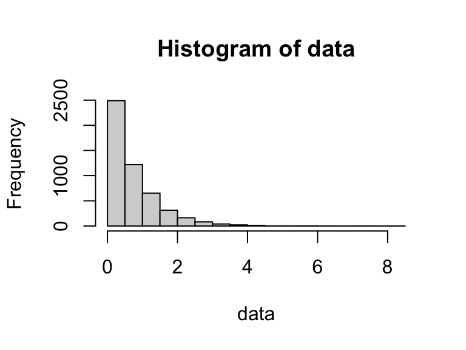

```r
set.seed(28951)
data <- rexp(5000, rate = 1.36)
hist(data)
```

```r
res <- strata.data(data, h = 2, n=500) # a 2-strata solution
summary(res)
```

```
#> <div style='margin-bottom:0.5rem'><span style='color:#0b7285;font-weight:700'>Stratification summary</span></div>
#> <div><span style='color:#0b7285;font-weight:600'>Strata (h):</span> 2 &nbsp; <span style='color:#0b7285;font-weight:600'>n:</span> 500 &nbsp; <span style='color:#0b7285;font-weight:600'>N:</span> 5000</div>
#> <div><span style='color:#0b7285;font-weight:600'>Data range:</span> [0.0001, 8.0169]  (d = 8.0168)</div>
#> <div><span style='color:#0b7285;font-weight:600'>Best-fit distribution:</span> exp</div>
#>
#>
#>
#> Table: Parameter estimate(s)
#>
#> |Parameter | Estimate|
#> |:---------|--------:|
#> |rate      | 1.359205|
```

Per-stratum results and totals

| Strata | OSB | Wh | Vh | WhSh | nh | Nh | fh |
| --- | --- | --- | --- | --- | --- | --- | --- |
| 1 | 0.93 | 0.72 | 0.07 | 0.188 | 235 | 3600 | 0.07 |
| 2 | 8.02 | 0.28 | 0.57 | 0.211 | 265 | 1400 | 0.19 |
| Total |  | 1.00 | 0.64 | 0.399 | 500 | 5000 | 0.10 |

Similarly, in order to find the OSB and other quantities, we can apply the **strata.distr()** function to a Exponential population. Based on the assumption from past knowledge that the population follows Exponential distribution with the given attributes such as the initial value, distance, parameters, etc., we can execute the following command to obtain the results:

```r
set.seed(28951)
data <- rexp(5000, rate = 1.36)
min(data); max(data); d=max(data)-min(data);d
```

```
#> [1] 5.747904e-05
#> [1] 8.016871
#> [1] 8.016814
```

```r
fit <- fitdist(data, distr="exp", method="mle")
fit
```

```
#> Fitting of the distribution ' exp ' by maximum likelihood
#> Parameters:
#>      estimate Std. Error
#> rate 1.359205 0.01922205
```

```r
res <- strata.distr(h=2, initval=5.748e-05, dist=8.017, distr = "exp",
             params = c(rate=1.36), n=500, N=5000) #a 2-strata solution
```

```
#> The program is running, it'll take some time!
```

```r
summary(res)
```

```
#> <div style='margin-bottom:0.5rem'><span style='color:#0b7285;font-weight:700'>Stratification summary</span></div>
#> <div><span style='color:#0b7285;font-weight:600'>Strata (h):</span> 2 &nbsp; <span style='color:#0b7285;font-weight:600'>n:</span> 500 &nbsp; <span style='color:#0b7285;font-weight:600'>N:</span> 5000</div>
#> <div><span style='color:#0b7285;font-weight:600'>Data range:</span> [0.0001, 8.0171]  (d = 8.0170)</div>
#> <div><span style='color:#0b7285;font-weight:600'>Best-fit distribution:</span> exp</div>
#>
#>
#>
#> Table: Parameter estimate(s)
#>
#> |Parameter | Estimate|
#> |:---------|--------:|
#> |rate      |     1.36|
```

Per-stratum results and totals

| Strata | OSB | Wh | Vh | WhSh | nh | Nh | fh |
| --- | --- | --- | --- | --- | --- | --- | --- |
| 1 | 0.93 | 0.72 | 0.07 | 0.185 | 236 | 3589 | 0.07 |
| 2 | 8.02 | 0.28 | 0.54 | 0.207 | 264 | 1411 | 0.19 |
| Total |  | 1.00 | 0.60 | 0.392 | 500 | 5000 | 0.10 |

## 8.7 Stratification for a Survey Variable with Uniform Distribution

If the study variable follows the Uniform distribution on the interval $[y_{0}, y_{L}]$, its two-parameter probability density function is given by:

$$\begin{equation}
f(y; a,b)=
\begin{cases}
\dfrac{1}{b-a}; & y > 0\\
\;\;\;\;0; & otherwise \\
\end{cases} \tag{39}
\end{equation}$$

where $a$ and $b$ are the continuous boundary parameters, i.e., $a$ and $b$ are the minimum and maximum values respectively.

### 8.7.1 DP Solution for Uniform Distribution

To solve the MPP formulated for Uniform distribution (39), we apply the algorithm using the DP technique discussed in Section 4. The recurrence relations used to determine the OSB are given by:

For the first stage, $k=1$, at $l_{1}^{*}=d_{1}$:

$$\begin{eqnarray}
\Phi_{1}d_{1}&=& \textrm{Sqrt}\Biggl\{
\sum\limits_{h=1}^{L}
\dfrac{d_{1}^{2}}{2\sqrt{3}(b-a)}\Biggr\} \tag{40}
\end{eqnarray}$$

And for the stages $k\geq2$:

$$\begin{eqnarray}
\Phi_{k}d_{k}&=&\min_{0\leq l_{k}\leq d_{k}}\Biggl\{
\textrm{Sqrt}\Biggl\{
\sum\limits_{h=1}^{L}
\dfrac{l_{k}^{2}}{2\sqrt{3}(b-a)}\Biggr\}+
\Phi_{k-1}(d_{k}-l_{k})\Biggr\} \tag{41}
\end{eqnarray}$$

Substituting the values of $a$, $b$, $y_{0}$ and $d$, the OSW ($l_{h}^{*}$) and the OSB ($y_{h}^{*}=y_{h-1}^{*}-l_{h}^{*}$) are obtained by executing the **strata.data()** function.

### 8.7.2 A Numerical Example for Uniform Distribution

A data following Uniform distribution of size $N=5000$ was simulated to demonstrate the application of the **stratifyR** package on a Uniform population. The data for Uniform distribution is simulated with the parameters $min = 2$ and $max=15$. When fitted, the minimum and maximum values in the simulated data are $[y_{0}, y_{L}] = [2.006522, 14.99764]$, which implies that $d=12.99112$.

To construct the OSB ($h = 2$) for the Uniformly-distributed data with a fixed total sample size of $450$, we use the following codes:

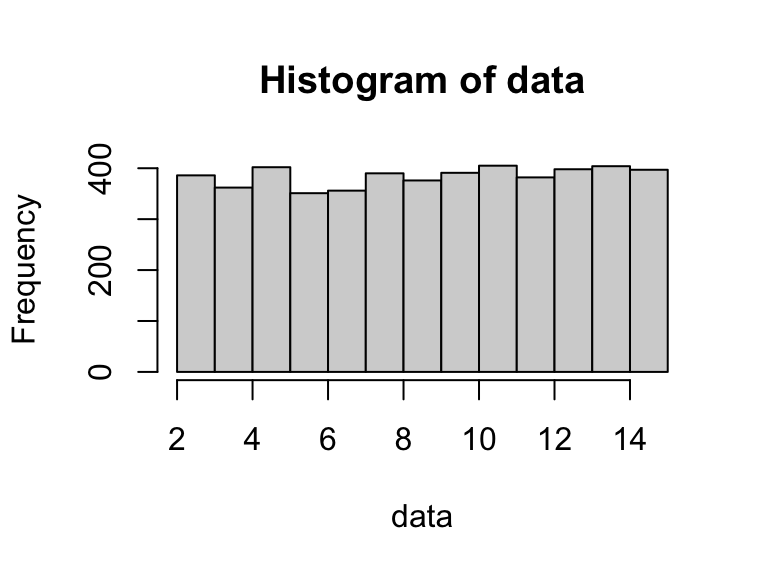

```r
set.seed(15669)
data <- runif(5000, min = 2, max = 15)
hist(data)
```

```r
res <- strata.data(data, h = 2, n=450) # a 2-strata solution
summary(res)
```

```
#> <div style='margin-bottom:0.5rem'><span style='color:#0b7285;font-weight:700'>Stratification summary</span></div>
#> <div><span style='color:#0b7285;font-weight:600'>Strata (h):</span> 2 &nbsp; <span style='color:#0b7285;font-weight:600'>n:</span> 450 &nbsp; <span style='color:#0b7285;font-weight:600'>N:</span> 5000</div>
#> <div><span style='color:#0b7285;font-weight:600'>Data range:</span> [2.0065, 14.9976]  (d = 12.9911)</div>
#> <div><span style='color:#0b7285;font-weight:600'>Best-fit distribution:</span> unif</div>
#>
#>
#>
#> Table: Parameter estimate(s)
#>
#> |Parameter |  Estimate|
#> |:---------|---------:|
#> |min       |  2.006522|
#> |max       | 14.997645|
```

Per-stratum results and totals

| Strata | OSB | Wh | Vh | WhSh | nh | Nh | fh |
| --- | --- | --- | --- | --- | --- | --- | --- |
| 1 | 8.5 | 0.49 | 3.55 | 0.919 | 220 | 2437 | 0.09 |
| 2 | 15 | 0.51 | 3.52 | 0.962 | 230 | 2563 | 0.09 |
| Total |  | 1.00 | 7.07 | 1.880 | 450 | 5000 | 0.09 |

Similarly, we can apply the **strata.distr()** function for the Uniform distribution where the arguments can be assumed from past knowledge. To construct the OSB for $h = 2$ for a hypothetical variable that follows Uniform distribution (with parameters $min=3$ and $max=15$) with a fixed total sample size of $450$ from a population of $5000$, the following command is used:

```r
# For a hypothetical uniform distribution, it does give a result
res <- strata.distr(h=2, initval=3, dist=12, distr = "unif",
                 params = c(min=3, max=15), n=450, N=5000)
```

```
#> The program is running, it'll take some time!
```

```r
summary(res)
```

```
#> <div style='margin-bottom:0.5rem'><span style='color:#0b7285;font-weight:700'>Stratification summary</span></div>
#> <div><span style='color:#0b7285;font-weight:600'>Strata (h):</span> 2 &nbsp; <span style='color:#0b7285;font-weight:600'>n:</span> 450 &nbsp; <span style='color:#0b7285;font-weight:600'>N:</span> 5000</div>
#> <div><span style='color:#0b7285;font-weight:600'>Data range:</span> [3.0000, 15.0000]  (d = 12.0000)</div>
#> <div><span style='color:#0b7285;font-weight:600'>Best-fit distribution:</span> unif</div>
#>
#>
#>
#> Table: Parameter estimate(s)
#>
#> |Parameter | Estimate|
#> |:---------|--------:|
#> |min       |        3|
#> |max       |       15|
```

Per-stratum results and totals

| Strata | OSB | Wh | Vh | WhSh | nh | Nh | fh |
| --- | --- | --- | --- | --- | --- | --- | --- |
| 1 | 9 | 0.5 | 3 | 0.866 | 225 | 2500 | 0.09 |
| 2 | 15 | 0.5 | 3 | 0.866 | 225 | 2500 | 0.09 |
| Total |  | 1.0 | 6 | 1.732 | 450 | 5000 | 0.09 |

## 8.8 Stratification for a Survey Variable with Normal Distribution

If the study variable follows the Normal distribution on the interval $[y_{0}, y_{L}]$, it has the following two-parameter probability density function:
$$\begin{equation}
f(y;\mu,
\sigma)=\dfrac{1}{\sigma\sqrt{2\pi}}\,exp\left\{-\dfrac{1}{2}\left(\dfrac{y-\mu}{\sigma}\right)^{2}\right\},\;\;\;\;\;\
-\infty < y < \infty \tag{42}
\end{equation}$$

where $\sigma > 0$ is a scale parameter and $\mu$ is the location parameter.

The following definitions of error function are worth noting since they are needed to simplify the integrations used to derive the stratum weight, mean and variance due to normal distribution.
$$\begin{eqnarray}
erf(z) = \dfrac{2}{\sqrt{\pi}}\int_{0}^{z}exp\left\{-y^{2}\right\}\,dy
\tag{43}
\end{eqnarray}$$
It can also be written as
$$\begin{eqnarray}\label{erf}
\dfrac{1}{\sqrt{2\pi}}\int_{0}^{z}exp\left\{-\dfrac{1}{2}y^{2}\right\}\,dy
= \dfrac{1}{2}\,erf\left(\dfrac{z}{\sqrt{2}}\right) \tag{44}
\end{eqnarray}$$

### 8.8.1 DP Solution for Normal Distribution

To solve the MPP formulated for Normal distribution (42), we apply the algorithm using the DP technique discussed in Section 4. The recurrence relations used to determine the OSB are given by:

For the first stage, $k=1$, at $l_{1}^{*}=d_{1}$:

$$\begin{eqnarray}
\Phi_{1}d_{1}&=& \textrm{Sqrt}\Biggl\{
\dfrac{\sigma^{2}}{2\sqrt{2\pi}}
\left[erf\left(\dfrac{d_{1}+y_{0}-\mu}{\sigma\sqrt{2}}\right) -
erf\left(\dfrac{y_{0}-\mu}{\sigma\sqrt{2}}\right)\right]\nonumber
\\[10pt]
&&
\times\left[\left(\dfrac{y_{0}-\mu}{\sigma}\right)exp\left(-\left(\dfrac{y_{0}-\mu}{\sigma\sqrt{2}}\right)^{2}\right)-
\left(\dfrac{d_{1}+y_{0}-\mu}{\sigma}\right)exp\left(-\left(\dfrac{d_{1}+y_{0}-\mu}{\sigma\sqrt{2}}\right)^{2}\right)\right]\nonumber\\[10pt]
&& +
\dfrac{\sigma^{2}}{4}\left[erf\left(\dfrac{d_{1}+y_{0}-\mu}{\sigma\sqrt{2}}\right)
-
erf\left(\dfrac{y_{0}-\mu}{\sigma\sqrt{2}}\right)\right]^{2}\nonumber\\[10pt]
&& -
\dfrac{\sigma^{2}}{2\pi}\left[exp\left(-\left(\dfrac{y_{0}-\mu}{\sigma\sqrt{2}}\right)^{2}\right)-
exp\left(-\left(\dfrac{d_{1}+y_{0}-\mu}{\sigma\sqrt{2}}\right)^{2}\right)\right]^{2}\Biggr\}
\tag{45}
\end{eqnarray}$$

And for the stages $k\geq2$:

$$\begin{eqnarray}
\Phi_{k}d_{k}&=&\min_{0\leq l_{k}\leq d_{k}}\Biggl\{
\textrm{Sqrt}\Biggl\{
\dfrac{\sigma^{2}}{2\sqrt{2\pi}} \left[
erf\left(\dfrac{d_{k}+y_{0}-\mu}{\sigma\sqrt{2}}\right) -
erf\left(\dfrac{(d_{k}-l_{k}+y_{0})-\mu}{\sigma\sqrt{2}}\right)
\right]\nonumber \\[10pt]
&&
\times\left[\left(\dfrac{(d_{k}-l_{k}+y_{0})-\mu}{\sigma}\right)exp\left(-\left(\dfrac{(d_{k}-l_{k}+y_{0})-\mu}{\sigma\sqrt{2}}\right)^{2}\right)\right.
\nonumber\\[10pt]
&& - \left.
\left(\dfrac{d_{k}+y_{0}-\mu}{\sigma}\right)exp\left(-\left(\dfrac{d_{k}+y_{0}-\mu}{\sigma\sqrt{2}}\right)^{2}\right)\right]\nonumber\\[10pt]
&& +
\dfrac{\sigma^{2}}{4}\left[erf\left(\dfrac{d_{k}+y_{0}-\mu}{\sigma\sqrt{2}}\right)
-
erf\left(\dfrac{(d_{k}-l_{k}+y_{0})-\mu}{\sigma\sqrt{2}}\right)\right]^{2}\nonumber\\[10pt]
&& -
\dfrac{\sigma^{2}}{2\pi}\left[exp\left(-\left(\dfrac{(d_{k}-l_{k}+y_{0})-\mu}{\sigma\sqrt{2}}\right)^{2}\right)-exp\left(-\left(\dfrac{d_{k}+y_{0}-\mu}{\sigma\sqrt{2}}\right)^{2}\right)\right]^{2}\Biggr\}
+ \Phi_{k-1}(d_{k}-l_{k})\Biggr\} \tag{46}
\end{eqnarray}$$

Substituting the values of $\mu$, $\sigma$, $y_{0}$ and $d$, the OSW ($l_{h}^{*}$) and the OSB ($y_{h}^{*}=y_{h-1}^{*}-l_{h}^{*}$) are obtained by executing the **strata.data()** function.

### 8.8.2 A Numerical Example for Normal Distribution

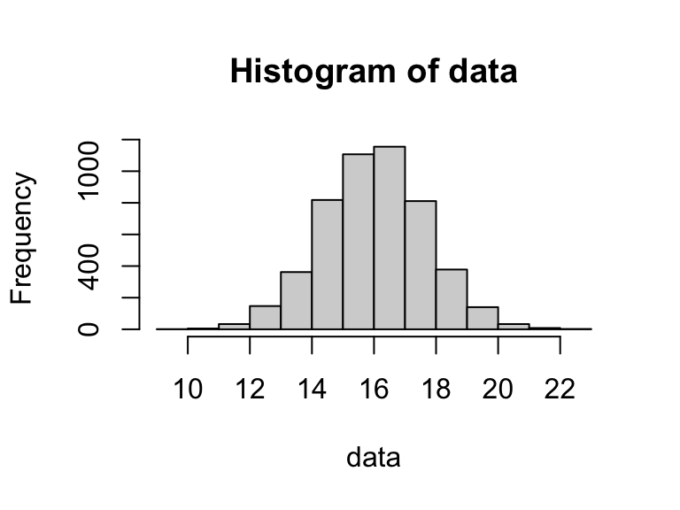

```r
set.seed(89821)
data <- rnorm(5000, mean = 16, sd = 1.65)
hist(data)
```

```r
res <- strata.data(data, h = 2, n=500) #construct a 2-strata solution
summary(res)
```

```
#> <div style='margin-bottom:0.5rem'><span style='color:#0b7285;font-weight:700'>Stratification summary</span></div>
#> <div><span style='color:#0b7285;font-weight:600'>Strata (h):</span> 2 &nbsp; <span style='color:#0b7285;font-weight:600'>n:</span> 500 &nbsp; <span style='color:#0b7285;font-weight:600'>N:</span> 5000</div>
#> <div><span style='color:#0b7285;font-weight:600'>Data range:</span> [9.9238, 22.5127]  (d = 12.5889)</div>
#> <div><span style='color:#0b7285;font-weight:600'>Best-fit distribution:</span> norm</div>
#>
#>
#>
#> Table: Parameter estimate(s)
#>
#> |Parameter |  Estimate|
#> |:---------|---------:|
#> |mean      | 16.010776|
#> |sd        |  1.662357|
```

Per-stratum results and totals

| Strata | OSB | Wh | Vh | WhSh | nh | Nh | fh |
| --- | --- | --- | --- | --- | --- | --- | --- |
| 1 | 16.01 | 0.5 | 0.98 | 0.493 | 245 | 2487 | 0.1 |
| 2 | 22.51 | 0.5 | 1.04 | 0.513 | 255 | 2512 | 0.1 |
| Total |  | 1.0 | 2.02 | 1.006 | 500 | 4999 | 0.1 |

Similarly, in order to find the OSB and other quantities, we can apply the **strata.distr()** function to a Normal population. Based on the assumption from past knowledge that the population follows Normal distribution with the given attributes such as the initial value, distance, parameters, etc., we can execute the following command to obtain the results:

```r
set.seed(89821)
data <- rnorm(5000, mean = 16, sd = 1.65)
min(data); max(data); d=max(data)-min(data);d
```

```
#> [1] 9.923816
#> [1] 22.51267
#> [1] 12.58885
```

```r
fit <- fitdist(data, distr="norm", method="mle")
fit
```

```
#> Fitting of the distribution ' norm ' by maximum likelihood
#> Parameters:
#>       estimate Std. Error
#> mean 16.010776 0.02350928
#> sd    1.662357 0.01662355
```

```r
res <- strata.distr(h=2, initval=9.923816, dist=12.58885, distr = "norm",
             params = c(mean=16.010776, sd=1.662357), n=500, N=5000)
```

```
#> The program is running, it'll take some time!
```

```r
summary(res)
```

```
#> <div style='margin-bottom:0.5rem'><span style='color:#0b7285;font-weight:700'>Stratification summary</span></div>
#> <div><span style='color:#0b7285;font-weight:600'>Strata (h):</span> 2 &nbsp; <span style='color:#0b7285;font-weight:600'>n:</span> 500 &nbsp; <span style='color:#0b7285;font-weight:600'>N:</span> 5000</div>
#> <div><span style='color:#0b7285;font-weight:600'>Data range:</span> [9.9238, 22.5127]  (d = 12.5889)</div>
#> <div><span style='color:#0b7285;font-weight:600'>Best-fit distribution:</span> norm</div>
#>
#>
#>
#> Table: Parameter estimate(s)
#>
#> |Parameter |  Estimate|
#> |:---------|---------:|
#> |mean      | 16.010776|
#> |sd        |  1.662357|
```

Per-stratum results and totals

| Strata | OSB | Wh | Vh | WhSh | nh | Nh | fh |
| --- | --- | --- | --- | --- | --- | --- | --- |
| 1 | 16.01 | 0.5 | 1 | 0.499 | 250 | 2499 | 0.1 |
| 2 | 22.51 | 0.5 | 1 | 0.501 | 250 | 2501 | 0.1 |
| Total |  | 1.0 | 2 | 1.000 | 500 | 5000 | 0.1 |

## 8.9 Stratification for a Survey Variable with Log-Normal Distribution

If the study variable follows the Log-normal distribution on the interval $[y_{0}, y_{L}]$, it has the following two-parameter probability density function:

$$\begin{equation}
f(y;\mu,\sigma)=\dfrac{1}{y\sigma\sqrt{2\pi}}\,exp\left\{-\dfrac{1}{2}\left(\dfrac{ln(y)-\mu}{\sigma}\right)^{2}\right\},\;\;\;\;\;\
y>0 \tag{47}
\end{equation}$$

where $\sigma > 0$ is a scale parameter and $\mu$ is the location parameter.

### 8.9.1 DP Solution for Log-Normal Distribution

To solve the MPP formulated for Log-Normal distribution (47), we apply the algorithm using the DP technique discussed in Section 4. The recurrence relations used to determine the OSB are given by:

For the first stage, $k=1$, at $l_{1}^{*}=d_{1}$:

$$\begin{eqnarray}
\Phi_{1}d_{1}&=&
\textrm{Sqrt}\Biggl\{\frac{1}{4}exp\left(2\mu+2\sigma^{2}\right)\left[
erf\left(\frac{ln(d_{1}+y_{0})-\mu-2\sigma^{2}}{\sigma\sqrt{2}}\right)\right.\nonumber
\\[10pt]
&& \left. -
erf\left(\frac{ln(y_{0})-\mu-2\sigma^{2}}{\sigma\sqrt{2}}\right) \right]
\left[ erf\left(\frac{ln(d_{1}+y_{0})-\mu}{\sigma\sqrt{2}}\right) -
erf\left(\frac{ln(y_{0})-\mu}{\sigma\sqrt{2}}\right)\right]\nonumber
\\[10pt]
&&
-\frac{1}{4}exp\left(2\mu+\sigma^{2}\right)\left[erf\left(\frac{ln(d_{1}+y_{0})-\mu-\sigma^{2}}{\sigma\sqrt{2}}\right)
- erf\left(\frac{ln(y_{0})-\mu-\sigma^{2}}{\sigma\sqrt{2}}\right)
\right]^{2}\Biggr\} \tag{48}
\end{eqnarray}$$

And for the stages $k\geq2$:

$$\begin{eqnarray}
\Phi_{k}d_{k}&=&\min_{0\leq l_{k}\leq d_{k}}\Biggl\{
\textrm{Sqrt}\Biggl\{
\frac{1}{4}exp\left(2\mu+2\sigma^{2}\right)\left[erf\left(\frac{ln(d_{k}+y_{0})-\mu-2\sigma^{2}}{\sigma\sqrt{2}}\right)\right.\nonumber
\\[10pt]
&& - \left.
erf\left(\frac{ln(d_{k}-l_{k}+y_{0})-\mu-2\sigma^{2}}{\sigma\sqrt{2}}\right)
\right] \left[
erf\left(\frac{ln(d_{k}+y_{0})-\mu}{\sigma\sqrt{2}}\right)\right.\nonumber
\\[10pt]
&& -\left.
erf\left(\frac{ln(d_{k}-l_{k}+y_{0})-\mu}{\sigma\sqrt{2}}\right)
\right]-\frac{1}{4}exp\left(2\mu+\sigma^{2}\right)\nonumber \\[10pt]
&&\times \left[
erf\left(\frac{ln(d_{k}+y_{0})-\mu-\sigma^{2}}{\sigma\sqrt{2}}\right) -
erf\left(\frac{ln(d_{k}-l_{k}+y_{0})-\mu-\sigma^{2}}{\sigma\sqrt{2}}\right)
\right]^{2}\Biggr\} + \Phi_{k-1}(d_{k}-l_{k})\Biggr\}. \tag{49}
\end{eqnarray}$$

Substituting the values of $\mu$, $\sigma$, $y_{0}$ and $d$, the OSW ($l_{h}^{*}$) and the OSB ($y_{h}^{*}=y_{h-1}^{*}-l_{h}^{*}$) are obtained by executing the **strata.data()** function.

### 8.9.2 A Numerical Example for Log-Normal Distribution

The ‘hies’ data of size $N=3566$ is used to demonstrate the application of the **stratifyR** package on Log-normal population. The ‘hies’ data comes from the HIES survey conducted in Fiji in the year 2010. The data contains only two aspects of the survey, namely Income and Expenditure. In this example, the variable Expenditure is used since it exhibits a 2-parameter Log-normal distribution with the shape and scale parameters as $meanlog = 9.2804934$ and $sdlog = 0.6917842$ respectively. The minimum and maximum values are $[y_{0}, y_{L}] = [991.24, 136539.1]$, which implies that $d=135547.8$.

```r
data(hies)
Expenditure <- hies$Expenditure
head(Expenditure);length(Expenditure)
```

```
#> [1] 10880.58  3633.28  3882.84  4862.67  9237.19  9637.24
#> [1] 3566
```

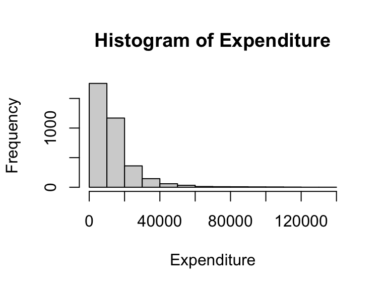

```r
hist(Expenditure)
```

```r
min(Expenditure); max(Expenditure); d=max(Expenditure)-min(Expenditure);d
```

```
#> [1] 991.24
#> [1] 136539.1
#> [1] 135547.8
```

```r
fit <- fitdist(Expenditure, distr="lnorm", method="mle")
fit
```

```
#> Fitting of the distribution ' lnorm ' by maximum likelihood
#> Parameters:
#>          estimate  Std. Error
#> meanlog 9.2804934 0.011584571
#> sdlog   0.6917842 0.008191452
```

```r
res <- strata.data(Expenditure, h = 2, n=500)
summary(res)
```

```
#> <div style='margin-bottom:0.5rem'><span style='color:#0b7285;font-weight:700'>Stratification summary</span></div>
#> <div><span style='color:#0b7285;font-weight:600'>Strata (h):</span> 2 &nbsp; <span style='color:#0b7285;font-weight:600'>n:</span> 500 &nbsp; <span style='color:#0b7285;font-weight:600'>N:</span> 3566</div>
#> <div><span style='color:#0b7285;font-weight:600'>Data range:</span> [991.2400, 136539.0600]  (d = 135547.8200)</div>
#> <div><span style='color:#0b7285;font-weight:600'>Best-fit distribution:</span> lnorm</div>
#>
#>
#>
#> Table: Parameter estimate(s)
#>
#> |Parameter | Estimate|
#> |:---------|--------:|
#> |meanlog   | 9.280493|
#> |sdlog     | 0.691784|
```

Per-stratum results and totals

| Strata | OSB | Wh | Vh | WhSh | nh | Nh | fh |
| --- | --- | --- | --- | --- | --- | --- | --- |
| 1 | 17206.65 | 0.77 | 14022946 | 2886.776 | 214 | 2749 | 0.08 |
| 2 | 136539.06 | 0.23 | 285033008 | 3868.016 | 286 | 817 | 0.35 |
| Total |  | 1.00 | 299055954 | 6754.792 | 500 | 3566 | 0.14 |

Similarly, in order to find the OSB and other quantities, we can apply the **strata.distr()** function to a Log-normal population. Based on the assumption from past knowledge that the population follows Log-normal distribution with the given attributes such as the initial value, distance, parameters, etc., we can execute the following command to obtain the results:

```r
res <- strata.distr(h=2, initval=10, dist=188, distr = "lnorm",
             params = c(meanlog=3.23, sdlog=0.65), n=500, N=1588)
```

```
#> The program is running, it'll take some time!
```

```r
summary(res)
```

```
#> <div style='margin-bottom:0.5rem'><span style='color:#0b7285;font-weight:700'>Stratification summary</span></div>
#> <div><span style='color:#0b7285;font-weight:600'>Strata (h):</span> 2 &nbsp; <span style='color:#0b7285;font-weight:600'>n:</span> 500 &nbsp; <span style='color:#0b7285;font-weight:600'>N:</span> 1588</div>
#> <div><span style='color:#0b7285;font-weight:600'>Data range:</span> [10.0000, 198.0000]  (d = 188.0000)</div>
#> <div><span style='color:#0b7285;font-weight:600'>Best-fit distribution:</span> lnorm</div>
#>
#>
#>
#> Table: Parameter estimate(s)
#>
#> |Parameter | Estimate|
#> |:---------|--------:|
#> |meanlog   |     3.23|
#> |sdlog     |     0.65|
```

Per-stratum results and totals

| Strata | OSB | Wh | Vh | WhSh | nh | Nh | fh |
| --- | --- | --- | --- | --- | --- | --- | --- |
| 1 | 39.66 | 0.76 | 63.79 | 5.423 | 247 | 1200 | 0.21 |
| 2 | 198 | 0.24 | 516.95 | 5.535 | 253 | 388 | 0.65 |
| Total |  | 1.00 | 580.74 | 10.958 | 500 | 1588 | 0.31 |

## 8.10 Stratification for a Survey Variable with Cauchy Distribution

If the study variable follows the Cauchy distribution on the interval $[y_{0}, y_{L}]$, its two-parameter probability density function is given by:

$$\begin{eqnarray}
f(y; \mu,
\sigma)=\dfrac{1}{{\pi}\sigma\left[1+\left(\dfrac{y-\mu}{\sigma}\right)^2\right]}
\;\;\;\;-\infty < y < +\infty \tag{50}
\end{eqnarray}$$

where $\mu$ is the location parameter which specifies the location of the peak of the distribution and $\sigma$ is the scale parameter, which specifies the half-width at half maximum of the distribution.

### 8.10.1 DP Solution for Cauchy Distribution

To solve the MPP formulated for Cauchy distribution (50), we apply the algorithm using the DP technique discussed in Section 4. The recurrence relations used to determine the OSB are given by:

For the first stage, $k=1$, at $l_{1}^{*}=d_{1}$:

$$\begin{eqnarray}
\Phi_{1}d_{1}&=&
\textrm{Sqrt}\Biggl\{\dfrac{1}{\pi^{2}}\left[\tan^{-1}\left(\dfrac{d_{1}+y_{0}-\mu}{\sigma}\right)-\tan^{-1}\left(\dfrac{y_{0}-\mu}{\sigma}\right)\right]\nonumber\\[10pt]
&&\times\left[\mu\sigma\ln\left(\left(d_{1}+y_{0}-\mu\right)^2+\sigma^2\right)+\left(\mu^2-\sigma^2\right)\tan^{-1}\left(\dfrac{d_{1}+y_{0}-\mu}{\sigma}\right)\right.\nonumber\\[10pt]
&&+\sigma\left(d_{1}+y_{0}\right)-\mu\sigma\ln\left(\left(y_{0}-\mu\right)^2+\sigma^2\right)\nonumber\\[10pt]
&&-\left.\left(\mu^2-\sigma^2\right)\tan^{-1}\left(\dfrac{y_{0}-\mu}{\sigma}\right)-\sigma
y_{0}\right]\nonumber\\[10pt]
&&-\left[\dfrac{1}{4\pi^{2}}\left[\sigma\ln\left(\left(d_{1}+y_{0}-\mu\right)^2+\sigma^2\right)+2\mu\tan^{-1}\left(\dfrac{d_{1}+y_{0}-\mu}{\sigma}\right)\right.\right.\nonumber\\[10pt]
&&-\left.\left.\sigma\ln\left(\left(y_{0}-\mu\right)^2+\sigma^2\right)-2\mu\tan^{-1}\left(\dfrac{y_{0}-\mu}{\sigma}\right)\right]\right]^{2}\Biggr\} \tag{51}
\end{eqnarray}$$

And for the stages $k\geq2$:

$$\begin{eqnarray}
\Phi_{k}d_{k}&=&\min_{0\leq l_{k}\leq d_{k}}\Biggl\{
\textrm{Sqrt}\Biggl\{
\dfrac{1}{\pi^{2}}\left[\tan^{-1}\left(\dfrac{d_{k}+y_{0}-\mu}{\sigma}\right)-\tan^{-1}\left(\dfrac{d_{k}-l_{k}+y_{0}-\mu}{\sigma}\right)\right]\nonumber\\[10pt]
&&\times\left[\mu\sigma\ln\left(\left(d_{k}+y_{0}-\mu\right)^2+\sigma^2\right)+\left(\mu^2-\sigma^2\right)\tan^{-1}\left(\dfrac{d_{k}+y_{0}-\mu}{\sigma}\right)\right.\nonumber\\[10pt]
&&+\sigma\left(d_{k}+y_{0}\right)-\mu\sigma\ln\left(\left(d_{k}-l_{k}+y_{0}-\mu\right)^2+\sigma^2\right)\nonumber\\[10pt]
&&-\left.\left(\mu^2-\sigma^2\right)\tan^{-1}\left(\dfrac{d_{k}-l_{k}+y_{0}-\mu}{\sigma}\right)-\sigma
y_{h-1}\right]\nonumber\\[10pt]
&&-\left[\dfrac{1}{4\pi^{2}}\left[\sigma\ln\left(\left(d_{k}+y_{0}-\mu\right)^2+\sigma^2\right)+2\mu\tan^{-1}\left(\dfrac{d_{k}+y_{0}-\mu}{\sigma}\right)\right.\right.\nonumber\\[10pt]
&&-\left.\left.\sigma\ln\left(\left(d_{k}-l_{k}+y_{0}-\mu\right)^2+\sigma^2\right)-2\mu\tan^{-1}\left(\dfrac{d_{k}-l_{k}+y_{0}-\mu}{\sigma}\right)\right]\right]^{2}
\Biggr\} + \Phi_{k-1}(d_{k}-l_{k})\Biggr\}. \tag{52}
\end{eqnarray}$$

Substituting the values of $\mu$, $\sigma$, $y_{0}$ and $d$, the OSW ($l_{h}^{*}$) and the OSB ($y_{h}^{*}=y_{h-1}^{*}-l_{h}^{*}$) are obtained by executing the **strata.data()** function.

### 8.10.2 A Numerical Example for Cauchy Distribution

The Boston data from the **MASS** package is used to demonstrate the application for Cauchy population. In this example, the variable ‘black’ is used since it exhibits a 2-parameter Cauchy distribution with the location and scale parameters as $location = 393.864307$ and $scale = 4.710457$ respectively. The minimum and maximum values are $[y_{0}, y_{L}] = [0.32, 396.9]$, which implies that $d=396.58$.

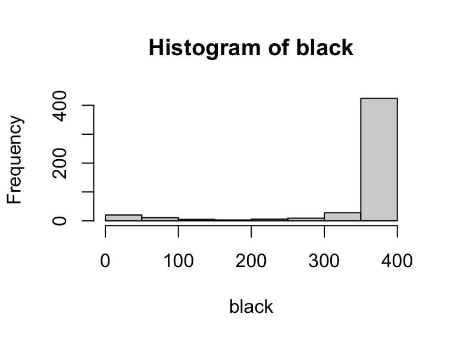

```r
data(Boston) #Housing Values in Suburbs of Boston
black = Boston$black
hist(black)
```

```r
min(black); max(black); d=max(black)-min(black);d
```

```
#> [1] 0.32
#> [1] 396.9
#> [1] 396.58
```

```r
fit <- fitdist(black, distr="cauchy", method="mle")
fit
```

```
#> Fitting of the distribution ' cauchy ' by maximum likelihood
#> Parameters:
#>            estimate Std. Error
#> location 393.863075  0.3060843
#> scale      4.709346  0.3395534
```

```r
res <- strata.data(black, h = 2, n=500)
summary(res)
```

```
#> <div style='margin-bottom:0.5rem'><span style='color:#0b7285;font-weight:700'>Stratification summary</span></div>
#> <div><span style='color:#0b7285;font-weight:600'>Strata (h):</span> 2 &nbsp; <span style='color:#0b7285;font-weight:600'>n:</span> 500 &nbsp; <span style='color:#0b7285;font-weight:600'>N:</span> 506</div>
#> <div><span style='color:#0b7285;font-weight:600'>Data range:</span> [0.3200, 396.9000]  (d = 396.5800)</div>
#> <div><span style='color:#0b7285;font-weight:600'>Best-fit distribution:</span> cauchy</div>
#>
#>
#>
#> Table: Parameter estimate(s)
#>
#> |Parameter |   Estimate|
#> |:---------|----------:|
#> |location  | 393.864327|
#> |scale     |   4.708422|
```

Per-stratum results and totals

| Strata | OSB | Wh | Vh | WhSh | nh | Nh | fh |
| --- | --- | --- | --- | --- | --- | --- | --- |
| 1 | 364.29 | 0.2 | 18335.38 | 27.028 | 101 | 101 | 1.00 |
| 2 | 396.9 | 0.8 | 58.14 | 6.103 | 399 | 405 | 0.99 |
| Total |  | 1.0 | 18393.52 | 33.131 | 500 | 506 | 0.99 |

Please note that for Cauchy distributions, one might get the error messages “simpleError in optim()…”. You can ignore this error message which simply indicates that when the data is fitted to all ten distributions, it gives errors while computing the parameters of those distributions which are not defined in the negative region. This happens with Cauchy distribution because it is defined on both positive and negative regions.

Similarly, in order to find the OSB and other quantities, we can apply the **strata.distr()** function to a Cauchy population. Based on the assumption from past knowledge that the population follows Cauchy distribution with the given attributes such as the initial value, distance, parameters, etc., we can execute the following command to obtain the results:

```r
#for a cauchy distribution with initial value of x0=-1, d=2 and
#location and scale parameters 0 and 1 respectively
res <- strata.distr(h=2, initval=-1, dist=2, distr = "cauchy",
             params = c(location=0, scale=1), n=500, N=5000)
```

```
#> The program is running, it'll take some time!
```

```r
summary(res)
```

```
#> <div style='margin-bottom:0.5rem'><span style='color:#0b7285;font-weight:700'>Stratification summary</span></div>
#> <div><span style='color:#0b7285;font-weight:600'>Strata (h):</span> 2 &nbsp; <span style='color:#0b7285;font-weight:600'>n:</span> 500 &nbsp; <span style='color:#0b7285;font-weight:600'>N:</span> 5000</div>
#> <div><span style='color:#0b7285;font-weight:600'>Data range:</span> [-1.0000, 1.0000]  (d = 2.0000)</div>
#> <div><span style='color:#0b7285;font-weight:600'>Best-fit distribution:</span> cauchy</div>
#>
#>
#>
#> Table: Parameter estimate(s)
#>
#> |Parameter | Estimate|
#> |:---------|--------:|
#> |location  |        0|
#> |scale     |        1|
```

Per-stratum results and totals

| Strata | OSB | Wh | Vh | WhSh | nh | Nh | fh |
| --- | --- | --- | --- | --- | --- | --- | --- |
| 1 | 0 | 0.5 | 0.08 | 0.07 | 250 | 2500 | 0.1 |
| 2 | 1 | 0.5 | 0.08 | 0.07 | 250 | 2500 | 0.1 |
| Total |  | 1.0 | 0.16 | 0.14 | 500 | 5000 | 0.1 |

# 9 Summary of Method Comparison Across All Supported Distributions

The three optimisation methods available in **stratifyR** — Dynamic Programming (`"dp"`), COBYLA (`"cobyla"`), and DIRECT-L + COBYLA (`"global"`) — produce the same optimal stratum boundaries and Neyman cost ($\sum W_h S_h$) in many cases, but can diverge meaningfully depending on the shape of the underlying distribution. To illustrate this, we applied all three methods to `strata.data()` with $h = 2$ (or $h = 3$ for Weibull, as in the earlier section) across all ten distributions supported by the package. The results are summarised in Table 1 below.

Table 1: Comparison of DP, COBYLA and GLOBAL methods across all ten distributions supported by stratifyR. WhShTot values shown for h=2 (h=3 for Weibull). Lower WhShTot indicates a more efficient stratification.

[output not shown]

Three distinct patterns emerge from Table 1. For heavy-tailed, right-skewed distributions — Pareto, Exponential, Gamma and Log-Normal — DP substantially outperforms COBYLA and GLOBAL. The reason is structural: for these distributions the theoretically optimal stratum boundary lies very close to the data minimum, in a region of rapidly changing density. COBYLA’s linear-approximation local search consistently misses this low-boundary optimum, settling instead in a nearby but suboptimal basin. DP avoids this problem entirely because it evaluates the objective on an exhaustive discrete grid and cannot be trapped by a local minimum. The GLOBAL method (DIRECT-L followed by COBYLA refinement) also misses this region in practice, because DIRECT-L’s uniform partition of the search space does not resolve the narrow optimal zone near the lower boundary finely enough before handing off to COBYLA.

For symmetric or bounded distributions — Uniform, Normal and Right-Triangular — all three methods converge to the same solution. The objective landscape for these distributions is smooth and unimodal, so COBYLA’s local search finds the global minimum reliably.

For the Weibull and Triangular distributions, COBYLA and GLOBAL report a marginally lower empirical $\sum W_h S_h$ than DP. As explained in Section 6.2, this does not mean DP is inferior: the two sets of methods are minimising different objectives. DP minimises the theoretical $W_h S_h$ derived analytically from the fitted distributional model (via `data.root`), whereas COBYLA and GLOBAL directly minimise the empirical $W_h S_h$ from the raw data. The reported WhShTot is always the empirical value, so methods optimising that quantity directly will tend to report a slightly lower number. For these distributions the optimal boundary falls in an interior region of the data range — accessible to COBYLA’s empirical search — so the two approaches reach similar, though not identical, solutions. The DP boundaries remain theoretically justified and generalisable to the underlying population.

For the Cauchy distribution, DP is marginally superior. The Cauchy’s extremely heavy tails and undefined mean make empirical optimisation unstable, whereas DP’s grid-based search over the fitted Cauchy recurrence relations is unaffected by the distributional anomalies.

Overall, **DP is the recommended and default method for `strata.data()`**, particularly when the survey variable is right-skewed or heavy-tailed. COBYLA and GLOBAL are provided as fast alternatives and can be useful for preliminary exploration or large datasets where computation time is a concern, but they should be used with caution for distributions in the first group above.

# References

Abramowitz, M, and I A Stegun. 1972. “Handbook of Mathematical Functions Dover Publications.” *New York*, 361.

Bellman, R E. 1957. *Dynamic Programming*. Princeton University Press.

Bühler, W, and T Deutler. 1975. “Optimal stratification and grouping by dynamic programming.” *Metrika* 22 (1): 161–75. https://doi.org/10.1007/BF01899725.

Cochran, W G. 1961. “Comparison of methods for determining stratum boundaries.” *Bulletin of the International Statistical Institute* 38 (2): 345–58.

Dalenius, T. 1950. “The Problem of Optimum Stratification.” *Scandinavian Actuarial Journal* 1950 (3-4): 203–13.

Dalenius, T. 1957. *Sampling in Sweden: contributions to the methods and theories of sample survey practice*. Almqvist; Wiksell.

Gablonsky, J M, and C T Kelley. 2001. “A Locally-Biased Form of the DIRECT Algorithm.” *Journal of Global Optimization* 21 (1): 27–37.

Gunning, P, and J M Horgan. 2004. “A new algorithm for the construction of stratum boundaries in skewed populations.” *Survey Methodology* 30 (2): 159–66.

Khan, E A, M G M Khan, and M J Ahsan. 2002. “Optimum stratification: a mathematical programming approach.” *Calcutta Statistical Association Bulletin* 52: 323–33.

Khan, M G M, N Ahmad, and Sabiha Khan. 2009. “Determining the Optimum Stratum Boundaries Using Mathematical Programming.” *Journal of Mathematical Modelling and Algorithms* 8 (4): 1–15. https://doi.org/10.1007/s10852-009-9115-3.

Khan, M G M, E A Khan, and M J Ahsan. 2003. “Theory & Methods: An Optimal Multivariate Stratified Sampling Design Using Dynamic Programming.” *Australian & New Zealand Journal of Statistics* 45 (1): 107–13.

Khan, M G M, N Nand, and N Ahmad. 2008. “Determining the Optimum Strata Boundary Points Using Dynamic Programming.” *Survey Methodology* 34 (2): 205–14.

Khan, M G M, D K Rao, A H Ansari, and M J Ahsan. 2015. “Determining Optimum Strata Boundaries and Sample Sizes for Skewed Population with Log-Normal Distribution.” *Communications in Statistics-Simulation and Computation* 44 (5): 1364–87.

Khan, M G M, K G Reddy, and D K Rao. 2015. “Designing Stratified Sampling in Economic and Business Surveys.” *Journal of Applied Statistics* 42 (10): 2080–99.

Khan, M G M, N Sehar, and M J Ahsan. 2005. “Optimum stratification for exponential study variable under Neyman allocation.” *Journal of the Indian Society of Agricultural Statistics* 59 (2): 146–50.

Lohr, S. 2009. *Sampling: Design and Analysis*. Nelson Education.

Nand, N, and M G M Khan. 2009. “Optimum Stratification for Cauchy and Power Type Study Variable.” *Journal of Applied Statistical Science* 16 (4): 453.

Neyman, J. 1934. “On the two different aspects of the representative method: the method of stratified sampling and the method of purposive selection.” *Journal of the Royal Statistical Society*, 558–625.

Powell, M J D. 1994. *A Direct Search Optimization Method That Models the Objective and Constraint Functions by Linear Interpolation*. (Dordrecht), 51–67.

Reddy, K G, M G M Khan, and D K Rao. 2014. “Computing optimal stratum boundaries for multivariate surveys.” *Computer Science and Engineering (APWC on CSE), 2014 Asia-Pacific World Congress on*, 1–7.

Reddy, Karuna Garan, Mohammad GM Khan, and Sabiha Khan. 2018. “Optimum Strata Boundaries and Sample Sizes in Health Surveys Using Auxiliary Variables.” *PloS One* 13 (4): e0194787.

Reddy, Karuna G, and MGM Khan. 2019. “Optimal Stratification in Stratified Designs Using Weibull-Distributed Auxiliary Information.” *Communications in Statistics-Theory and Methods* 48 (12): 3136–52.

Särdnal, C E, B Swensson, and J H Wretman. 1992. *Model Assisted Survey Sampling*.